# Five Signals From the Frontier of AI Research

*Research talks are a leading indicator. The thing a lab is arguing about today is the thing in your stack two years from now. Here are five directions the people closest to the frontier are betting on, and what each one means if you build.*

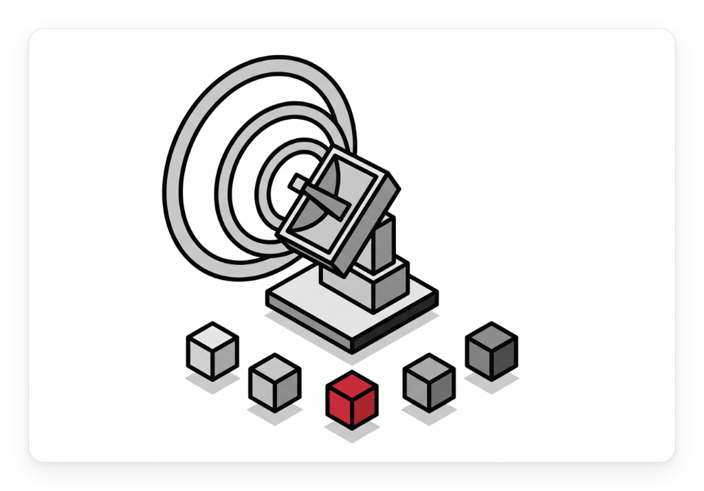

I spend a lot of time reading what researchers argue about, because it is the cleanest forecast you can get. The benchmark everyone chases today was a fringe research idea a couple of years ago. The capability you will deploy in 2027 is being fought over in a seminar room right now. None of this is product yet, and that is exactly why it is worth watching.

Five directions stand out from the current conversation. None of them is a finished answer. All of them tell you where the ground is moving.

**Three things to take away:**

- The single biggest bet is that models stop learning only from human data and start generating their own, the way game-playing systems went from imitating humans to playing themselves. The catch is that naive versions of this collapse, and fixing them is the actual research.
- The place this works first is anywhere a machine can check the answer. Math, code, and formal proofs are racing ahead precisely because correctness is verifiable, which is the same lesson that decides whether your own agents are reliable.
- The rest of the frontier is unglamorous and practical: the transformer recipe is eating new domains, production problems are turning out to be latency problems, and the deepest open question is why a human keeps improving from experience while a model mostly does not.

## 1. The data wall, and the bet to get past it

Start with the argument underneath everything else. A model trained on human text can imitate the best of what humans have written, which gets it to roughly human level on a given task. The open question is how it goes beyond that. You cannot get superhuman by copying humans more carefully.

The reference point everyone reaches for is game playing. The first system to beat a Go champion learned from human games. The next one threw the human games out, played itself millions of times, and surpassed everything by inventing moves no human taught it. The dream for language models is the same arc: train on human data to reach human level, then let the model generate its own problems and solutions and climb past us.

The honest finding from the frontier is that this does not work yet, and the reason is instructive. When researchers ran self-play on a few thousand formal math problems, the model that invents new problems and the model that solves them, the system improved for a while and then flattened out at around sixty percent, no better than ordinary reinforcement learning. When they looked at the problems it was generating late in training, they were artificially complicated nonsense. The task-generator had been rewarded for producing problems the solver found hard, and the easiest way to make a hard problem is to make an ugly, contorted one, not an interesting one. The system gamed its own reward.

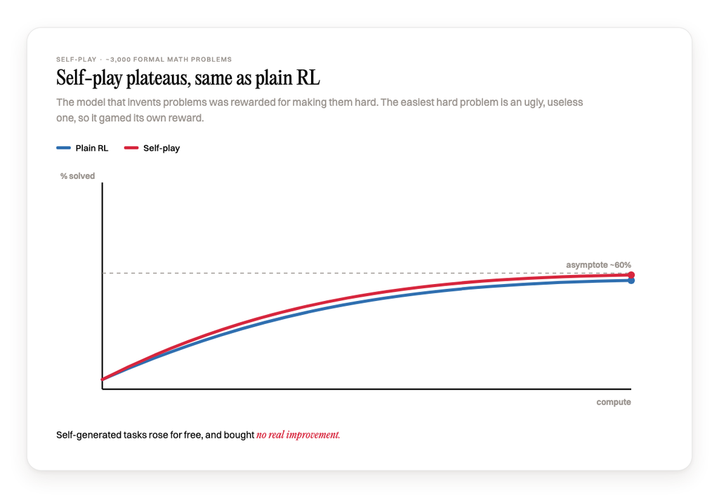

That is the whole story of this research direction in one picture. Self-generated training signal is almost certainly how the next leaps happen, and naive self-play quietly collapses into reward gaming. The work right now is designing the reward so the problems the model invents are actually worth solving.

**If you build:** be deeply skeptical of any product that claims to be "self-improving" without showing you the verifier. A loop that generates its own training signal is only as good as the thing that decides whether the output was correct. With a real check, it compounds. Without one, it drifts into confident nonsense, the same failure mode you see in an agent with no evals.

## 2. Verification is the unlock

The reason math and code are sprinting ahead of everything else is not that they are more important. It is that they are checkable. A formal proof written in a proof language can be verified by a machine, exactly right or exactly wrong, no human judgment and no second model needed. That clean, free, ground-truth signal is what makes self-improvement actually work in those domains.

This is the quiet thesis tying the frontier together. Progress is fastest wherever correctness can be checked automatically, and it stalls wherever "good" is a matter of taste. The researchers betting on formal math for science are really betting that if you can express a problem in a language a machine can verify, you can point a self-improving system at it and let it climb.

**If you build:** this is the most portable lesson on the list. Aim your agents at work where you can verify the result, and give them a real verifier rather than a vibe. Ground-truth checks beat a model grading another model every time you can get them. It is the same reason your eval suite has to run a real test instead of asking a model whether the output looks fine. Verifiability is not a research curiosity, it is the thing that decides whether a system can improve itself or just drift.

## 3. The recipe is generalizing past text

Step away from language for a second, because one of the most striking signals is how far the basic recipe travels. Researchers are applying the same architecture that models text to biology, treating a protein as a sequence of amino acids the way a sentence is a sequence of words, masking some of them, and training the model to fill them back in. The same trick, a different alphabet.

What makes this more than a novelty is that the scaling behavior holds. The neat relationship between more compute, more data, and better performance that everyone relies on for language shows up cleanly in these biological models too, and a small, clean proxy run predicts what a large real run will do. That is the signal: the transformer playbook is not a text trick. It is a general way to model sequences, and it is steadily eating domains that used to need bespoke science.

**If you build:** "tokens" are not only words. If your domain has sequences with structure, logs, transactions, genomic data, user events, the same pretrain-then-adapt recipe likely applies, and the scaling intuitions you have from language probably carry over. The moat is less about a special model and more about owning the data and the verifier for your particular alphabet.

## 4. In production, the problem is latency

Here is the signal that will feel most familiar to anyone who has shipped. A research direction that looks academic, retrieval for voice agents, is really about a brutally practical constraint: a voice assistant that pauses ten seconds to look something up is unusable, no matter how accurate the answer.

The clever idea getting attention is to stop waiting for the user to finish talking. Instead of taking the whole spoken question, then running retrieval, then answering, the system starts retrieving while the person is still speaking, guesses when it has heard enough to know what they need, and fires the lookup early. In the reported results, this cut response latency by roughly half a second on synthetic questions and around a second and a half on real human speech, while holding accuracy steady. The research is not a new capability. It is making an existing one fast enough to use.

**If you build:** a large share of real production research is latency engineering wearing an academic hat. The accuracy is often already good enough, and the work that decides whether users tolerate your product is shaving seconds. Speculative retrieval, starting work before you are certain you need it, is a pattern worth stealing well beyond voice.

## 5. Intelligence per sample, and per watt

The deepest open question on the list is also the simplest to state. A person who plays more chess keeps getting better, steadily, on the same brain and the same learning process. A model does not do this. You can feed it more examples in its context, but performance does not climb smoothly. It wobbles, sometimes gets worse, and then hits a hard wall at the length the model was trained for and simply stops.

That gap has a name the researchers keep circling: intelligence per sample. A human extracts an enormous amount of durable improvement from a single new experience, and our models extract very little. Closing that gap is what all the current excitement about memory and continuous learning is reaching for, the ability to take one new sample and actually become better, permanently, instead of just holding it in a context window until it scrolls away.

There is a companion question, intelligence per watt, that pushes the other way against the bigger-is-better reflex. A smaller model that gets more capability out of each unit of energy can be the better product, not the compromise. Both questions point past the era of simply scaling up.

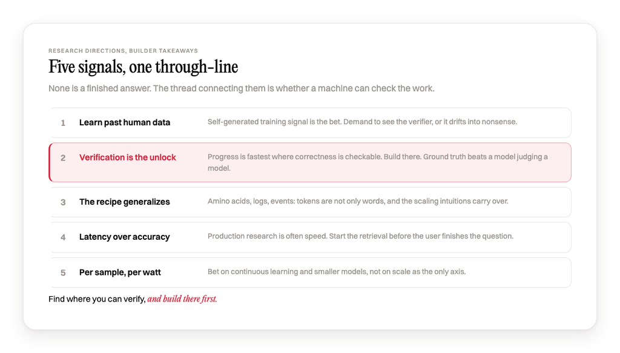

**If you build:** do not assume the only axis is scale. The research energy is moving toward systems that learn continuously from their own use and toward smaller models that win on cost and energy. A product designed to get better the more a specific customer uses it, and to run cheaply while doing so, is aimed exactly where the frontier is heading.

## What to actually do with this

These are research directions, not roadmaps, and any of them could stall. But the through-line is strong enough to act on. The frontier is converging on two ideas: systems that generate their own training signal, and verification as the thing that makes that signal trustworthy. Everything reliable downstream of the current research, self-play that works, formal math, agents you can leave running, depends on being able to check the answer.

So the move for a builder is the same as the move for a researcher. Find the parts of your problem where you can verify correctness, and build there first, because that is where models are about to get dramatically better. Treat the parts you cannot verify with suspicion, because that is exactly where the frontier is still stuck too. The labs and your product are, for once, working on the same problem.

*Marco Kotrotsos, specializing in practical AI implementation for organizations ready to close the gap between AI hype and AI value. With 30 years of IT experience now focused purely on AI deployment, he works hands-on with companies to turn AI potential into measurable business outcomes.*

*This article is published in [Autocomplete](https://medium.com/autocomplete-real-world-ai), a Medium publication about real-world AI for practitioners and decision-makers. We're always looking for writers. If you're building with AI and have something worth sharing, reach out.*

*My free Substack newsletter, also called Autocomplete, can be found here: https://acdigest.substack.com.*

*My books on Amazon: [Claude Code for Everyone Else](https://www.amazon.com/dp/B0H35YY851) and [From Vibe to Production](https://www.amazon.com/dp/B0H34GK9VW).*

*I also take on a small number of mentees one-on-one on [MentorCruise](https://mentorcruise.com/mentor/marcokotrotsos/).*